# Indicadores de informalidad en el Perú en el período 2011 – 2022

Joselin Chávez, Aly Fiorentino, Alexis Flores, Bianca Luzón

Q-Lab - Pontificia Universidad Católica del Perú

## I. Introducción

De acuerdo con la [ONU (2015)](https://news.un.org/es/audio/2015/04/1408961), la informalidad es un problema crónico, y en países como Perú, Bolivia y Honduras 8 de cada 10 trabajadores jóvenes cuentan con empleos informales. No obstante, la pandemia incrementó las cifras, e incluso luego de dos años aún América Latina no ha logrado regresar a niveles de empleo del 2019, según la [OIT (2021)](https://www.inei.gob.pe/).

En el caso del Perú, si bien se ha dado una aparente recuperación respecto a la tasa de informalidad de los años 2020 (75.3%) y 2021 (76.8%), el promedio de los primeros tres trimestres del 2022 asciende a 73.77%, aún superior que la tasa pre pandemia, según los datos presentados por el [INEI (2023)](https://www.ilo.org/wcmsp5/groups/public/---americas/---ro-lima/documents/publication/wcms_836196.pdf).

Dado ello, en el presente documento se busca realizar un análisis descriptivo del sector informal en el mercado laboral peruano y comparar las variaciones a lo largo de los años 2011 al 2022[^1] poniendo énfasis en los años de la pandemia del COVID-19. Para este fin, se utilizará el software estadístico R, en específico, el paquete de manejo de bases de datos *“tidyverse”* y el paquete gráfico *“ggplot2”*.

Adicionalmente, se realizará un análisis comparativo entre los 24 departamentos del Perú y la Provincia Constitucional del Callao, para lo cual se utilizarán los paquetes *“sf”*, *“purrr”*, *“ggrepel”* y *“gganimate”* a fin de manipular datos espaciales y presentar mapas con las tasas de informalidad.

## II. Problemática de la Informalidad

De acuerdo con Salazar-Xirinachs (2018), el concepto de informalidad fue acuñado por el economista británico Keith Hart en un informe de misión sobre Kenya elaborado por la OIT en 1972, en la que se encontró que las personas pobres lograban sobrevivir mediante oficios, actividades y tareas que se realizaban a pequeña escala y –sin ser actividades delictivas– a menudo se encontraban al margen de las normativas vigentes.

Desde entonces, el término informalidad posee diversos significados para diferentes personas, pero generalmente tiene connotaciones negativas como: trabajadores desprotegidos, regulación excesiva, baja productividad, competencia desleal, evasión de la ley, bajos pagos o no pago de impuestos y trabajo “subterráneo” o en la sombra, según Perry et al. (2007).

Dado que en este documento se propone identificar los principales indicadores de la informalidad en el Perú, es relevante definir algunos conceptos que son usados con frecuencia para referirse a la informalidad de acuerdo con lo indicado por Vargas-Espejo & Vilchez Astucuri (2016):

Economía informal: Conjunto de actividades económicas desarrolladas por los trabajadores y las unidades productivas que no cumplen con las regulaciones previstas por el estado para el ejercicio de sus actividades. Está compuesta por el sector informal y el empleo informal.

- *Sector informal*: Conformado por las unidades productivas no constituidas en sociedad que no están registradas en la administración tributaria (SUNAT). Para el caso de las unidades productivas del sector primario (Agricultura, Pesca y Minería) no constituidas en sociedad, se considera que todas pertenecen al sector informal. También excluye a las cuasi sociedades, es decir, empresas no constituidas en sociedad que funciona en todo –o en casi todo– como si fuera una sociedad.
- *Empleo informal o informalidad laboral*: Son aquellos empleos que no cuentan con los beneficios estipulados por ley como el acceso a la seguridad social pagada por el empleador, vacaciones pagadas, licencia por enfermedad, etc.

Desde el punto de vista de Gonzalez (2022), en el Perú, la informalidad es un problema estructural grave que dificulta la pronta y acelerada recuperación económica que necesita el país. La formalización de la economía debe ser uno de los principales objetivos de las políticas públicas y para ello necesitamos entender la complejidad del problema, tanto en sus raíces como en sus consecuencias.

En el año 2021, la tasa de empleo informal del país, fue de 76,8%; siendo 1,5 puntos porcentuales más que en el año 2020 y 4,1 puntos porcentuales más que en el 2019 a consecuencia de la pandemia del COVID-19. Como se señala en el Diario Gestión (2022), la mayoría de los empleos informales se han generado en el área urbana, a través de la mayor contratación de mano de obra no calificada en empresas de uno a 10 trabajadores, concentradas principalmente en unidades productivas del sector agropecuario.

## III. Metodología

### a. Base de Datos

Para la elaboración de la base de datos se recurrió principalmente a las estadísticas armadas de empleo de la página web del [INEI (2023)](https://www.inei.gob.pe/estadisticas/indice-tematico/ocupacion-y-vivienda/) para los años 2011 al 2021, y se completó el año 2022 con la Encuesta Nacional de Hogares [(ENAHO)](https://iinei.inei.gob.pe/microdatos/) a través de su plataforma de microdatos. Asimismo, se consideró la información geoespacial de los 24 departamentos del Perú y la Provincia Constitucional del Callao obtenido de [GEOGPS (2015)](https://www.geogpsperu.com/2014/03/base-de-datos-peru-shapefile-shp-minam.html).

Así, se cuentan con 12 observaciones y con 94 variables en total. De esta manera, se estructuró la base de datos con las siguientes variables:

- Base principal, compuesta por:
  - Tasa de informalidad
  - Tasa de informalidad rural
  - Tasa de informalidad urbana
  - Tasa de informalidad en hombres
  - Tasa de informalidad en mujeres
  - Población ocupada informal desde 14 hasta 24 años
  - Población ocupada informal desde 25 hasta 44 años
  - Población ocupada informal desde 45 hasta 64 años
  - Población ocupada informal de 65 años a más
  - Población ocupada informal en microempresas (1 a 10 trabajadores)
  - Población ocupada informal en pequeñas empresas (11 a 50 trabajadores)
  - Población ocupada informal en medianas y grandes empresas (51 trabajadores a más)
  - Población ocupada de 14 a 24 años
  - Población ocupada de 25 a 44 años
  - Población ocupada de 45 a 64 años
  - Población ocupada de 65 años a más
  - Población ocupada en microempresas
  - Población ocupada en pequeñas empresas
  - Población ocupada en medianas y grandes
  - Población ocupada en empresas de tamaño no identificado
  - Ingresos promedio mensuales
  - Ingresos promedio mensuales de trabajadores formales
  - Ingresos promedio mensuales de trabajadores informales
  - Poblacipon Economicamente Activa (PEA) ocupada
  - PEA total (ocupada y desocupada)
  - PEA ocupada urbana
  - PEA ocupada rural
  - PEA ocupada hombres
  - PEA ocupada mujeres
- Informalidad en Regiones: considera la tasa de informalidad y la población total ocupada de los 24 departamentos del Perú y la Provincia Constitucional del Callao. Adicionalmente, se cuenta con información desagragada para el departamento de Lima (Lima Metropolitana y Lima Provincias).
- Datos geográficos a nivel de departamentos: se tomaron datos geoespaciales por límite departamental (un shapefile que almacena datos atributos y ubicación geográfica).

### b. Preprocesamiento

De los datos se observa que es conveniente contar con algunas variables relevantes adicionales que permitan mejoras en el análisis y compresión de los datos. De esta manera, a partir de los datos establecidos, se construyen variables como:

- PEA ocupada femenina
- PEA desocupada
- PEA ocupada rural
- Tasa de informalidad por rango de edades (cuatro variables adicionales)
- Tasa de informalidad por tamaño de empresa (tres variables adicionales)
- Tasa de desempleo

Por otro lado, si se realiza una inspección visual de la base no es notable alguna inconsistencia en los datos debido a su extensión (es una base pequeña de inspección sencilla). Sin embargo, generando algunos estadísticos descriptivos para entender las bases de datos, que en este caso son dataframes, es fácil notar que todas son variables numéricas. Asimismo, puede notarse que en los años elegidos (2011-2022), el promedio de la tasa de informalidad es de 73.73% de alrededor de 16.2 millones de trabajadores en todo el Perú. Asimismo, la tasa de desempleo ha sido en promedio 4.5% en los últimos 11 años, llegando hasta un máximo de 7.4% registrado en el periodo de la pandemia (2020).

Descripción de la informalidad

```
## Base$tasa_inf
##        n  missing distinct     Info     Mean      Gmd      .05      .10
##       12        0       12        1    73.73    1.647    72.23    72.45
##      .25      .50      .75      .90      .95
##    72.69    73.45    74.50    75.32    76.02
##
## lowest : 71.97162 72.43837 72.54650 72.74092 72.83699
## highest: 73.76779 74.31488 75.06388 75.34852 76.84696
##
## Value      71.97162 72.43837 72.54650 72.74092 72.83699 73.15043 73.74371
## Frequency         1        1        1        1        1        1        1
## Proportion    0.083    0.083    0.083    0.083    0.083    0.083    0.083
##
## Value      73.76779 74.31488 75.06388 75.34852 76.84696
## Frequency         1        1        1        1        1
## Proportion    0.083    0.083    0.083    0.083    0.083
```

Estadísticas descriptivas

```
##     PEA_ocu         Tasa_desempleo   Ing_prom_men  Ing_prom_men_f
##  Min.   :14901782   Min.   :3.510   Min.   :1069   Min.   :1369
##  1st Qu.:15647826   1st Qu.:3.863   1st Qu.:1199   1st Qu.:1694
##  Median :16058178   Median :3.982   Median :1287   Median :1911
##  Mean   :16227648   Mean   :4.498   Mean   :1279   Mean   :1841
##  3rd Qu.:16862398   3rd Qu.:4.553   3rd Qu.:1372   3rd Qu.:1973
##  Max.   :17843094   Max.   :7.413   Max.   :1443   Max.   :2234
##  Ing_prom_men_i
##  Min.   :528.0
##  1st Qu.:619.1
##  Median :682.6
##  Mean   :663.0
##  3rd Qu.:708.1
##  Max.   :795.9
```

En esta línea, el promedio del salario mensual en el mismo periodo es de 1,279 soles; sin embargo, exite una gran brecha entre el salario promedio un trabajador formal ubicado en 1,841 soles y el salario promedio de un trabajador informal ubicado en 663 soles al mes.

Por otro lado, si bien las bases asociadas a las regiones o departamentos contienen valores perdidos que corresponden a la desagregación de la región Lima (Lima Metropolitana y Lima Provincias), ello no resulta en un problema dado que para la realización del comparativo entre las regiones podemos omitir la desagregación y trabajar con el agregado de Lima que no contiene valores perdidos.

Valores perdidos en la base principal y de regiones

```
## [1] FALSE
```

```
## [1] TRUE
```

```
## [1] TRUE
```

```
## # A tibble: 6 × 3
##   variable           n_miss pct_miss
##   <chr>               <int>    <dbl>
## 1 LIMA_METROPOLITANA      1     8.33
## 2 LIMA_PROVINCIAS         1     8.33
## 3 AMAZONAS                0     0
## 4 ANCASH                  0     0
## 5 APURIMAC                0     0
## 6 AREQUIPA                0     0
```

### c. Técnicas y algoritmos aplicados

Los datos previamente descritos serán trabajados un entorno y lenguaje de programación libre, en este caso R, para computación estadística y gráficos que incluye “paquetes” los cuales son colecciones de funciones, datos y código compilado en un formato bien definido clasificados mediante “librerías”, las cuales son conjuntos de instrucciones que albergan scripts y son ejecutados mediante instrucciones. [[Arias (2021)](https://totumat.com/2021/04/23/r-librerias-datos/); [R (2023)](https://www.r-project.org/)]

Los paquetes y librerías que se utilizarán en el documento de trabajo son:

- **[tidyverse](https://www.tidyverse.org/)**: el paquete incluye librerías que funcionan en armonía para el análisis de datos cotidianos. Comparten representaciones de datos y diseño de API comunes para visualizar, manipular, ordenar e importar data.
  - **[ggplot2](http://www.castrolab.org/teaching/data_analysis/visualizacion-de-datos-usando-ggplot2.html)**: crea visualizaciones de datos usando la gramática de los gráficos, trabaja mediante capas en el cual cada una proporciona información sobre cómo queremos representar los datos. La ventaja del paquete es la gran cantidad de personalización y, además, proporciona una interfaz simple para especificar los elementos de un gráfico.
    - **[ggrepel](https://r-charts.com/es/ggplot2/anotaciones-texto/)**: proporciona funciones que hacen que las etiquetas se repelen tanto como sea posible ya que los textos y las etiquetas se colocan en las coordenadas que selecciones, pero se pueden solapar.
    - **[gganimate](https://gganimate.com)**: amplia la gramática de gráficos implementadas por *“ggplot”* para incluír la descripción de la animación.
  - **[purrr](https://purrr.tidyverse.org/)**: permite trabajar con funciones y vectores mediante un conjunto completo y consistente de herramientas de programación mejoradas de R que realizan lo mismo de estas, pero con otras ventajas: simple de recordar, completa y es sintácticamente estable.
- **[sf](https://bookdown.org/matiasandina/R-intro/estadistica-espacial.html)**: codifica datos de vectores espaciales (vértices de polígonos, sistemas de coordenadas y líneas, etc.) de forma simple y estandarizada. Se une a otras librerías como: *“GDAL”* para leer y escribir datos, a *“GEOS”* para operaciones geométricas y a *“PROJ”* para conversiones de proyección y transformaciones de datos. Se obtienen formas geográficas vectoriales, lo cual permite almacenar una estructura de datos vectoriales que contienen atributos mediante varias capas. Cada capa tiene información diferente y se muestra u oculta en función del nivel de zoom del mapa, lo que permite una visualización más clara.
- **[reshape2](https://rpubs.com/enralvar/ReShape2)**: permite la transformación de datos adaptandolos a formatos ancho y largo.

Otra librería principal a utilizar, dentro del paquete *“tidyverse”*, es [*dplyr*](https://dplyr.tidyverse.org/), la cual presenta conjunto de funciones que permite resolver los desafíos de manipulación de datos más comunes permitiendo ordenar las bases de datos de tal manera que las variables se puedan analizar mediante los demás paquetes. Entre las funciones más usuales a utilizar son:

- mutate() agrega nuevas variables que son funciones de variables existentes
- select() elige variables en función de sus nombres.
- filter() selecciona casos en función de sus valores.
- summarise() reduce múltiples valores a un solo resumen.
- arrenge() cambia el orden de las filas.

## IV. Resultados y Discusión

La tasa de informalidad en el Perú de los años 2011 al 2022 (considerando un promedio de los tres primeros trimestres) evidencia una reducción sistemática hasta el año 2019 con un punto mínimo en el 2016 (72%). Sin embargo, a raíz de la pandemia del COVID-19 la informalidad retrocedió a niveles superiores a lo registrado en la última década. De esta manera, en 2020 se registró una tasa de informalidad de 75.3% (2.6 puntos porcentuales por encima de 2019) y de 76.8% en el 2021 (4.1 puntos porcentuales por encima de 2019).

Si bien la tasa de informalidad en 2022 ha decrecido considerablemente respecto al año anterior (3.1 puntos porcentuales por debajo del 2021), aún se encuentra 1 punto porcentual por encima de la tasa prepandemia[^2] a casi tres años de iniciado el contagio masivo en Perú.

[figure not shown]

Así, por un lado hubo un crecimiento del número de trabajadores informales a nivel nacional, pero también podemos notar que la población economicamente activa, conocida como PEA, se contrajo duramente, en especial la PEA ocupada. Con lo cual, una parte de esta PEA ocupada pasa a formar parte de la PEA desocupada, incrementada a niveles no observados durante la muestra, o dejaron de trabajar y de buscar trabajo, es decir, se convierten en población inactiva (no contada en la PEA).

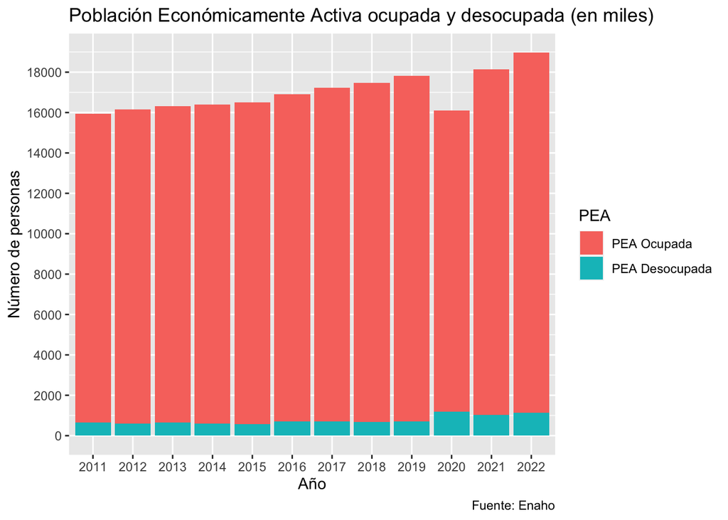

De esta manera, la tasa de desempleo se vio severamente afectada pasando de 3.9% en 2019 a 7.4% en 2020, a causa del despido masivo de trabajadores por la crisis económica generada por la pandemia iniciada en dicho año. Asimismo, la tasa de desempleo aún no retorna a su nivel prepandemia y se encuentra en 5.9% en 2022.

[figure not shown]

**Indicadores de Informalidad**

En lo que respecta a la tasa de informalidad a nivel de área de residencia se evidencia que la informalidad en áreas rurales son históricamente superiores a la informalidad en zonas urbanas, asimismo, hasta antes de la pandemia mantenian una dinámica similar, empero el choque del COVID-19 se modificó esta tendencia. En este sentido, el incremento de la informalidad en las zonas rurales fue de 0.9 puntos porcentuales entre 2020 (96.1%) y 2019 (95.2%); mientras que, el área urbana tuvo un crecimiento mucho mayor de la informalidad hacia 2021 con un registro de 71.4%, es decir, 5 puntos porcentuales por encima de los niveles prepandemia.

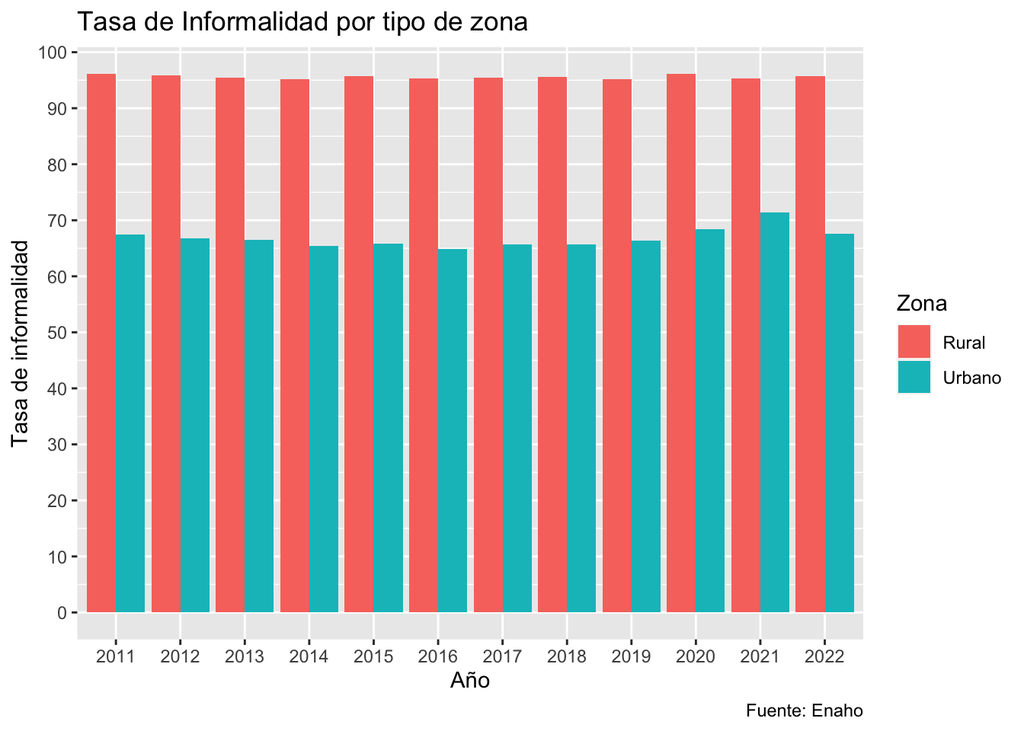

De igual manera, la tasa de informalidad por sexo aumentó en ambos casos en los años 2020 y 2021, principalmente la tasa de informalidad de la población masculina se registró en 75.4%, es decir 5 puntos porcentuales por encima de 2019, pero en el 2022 se produjo un retorno rápido a una tasa de informalidad muy cercana a los niveles pre COVID-19. No obstante, la tasa de informalidad de la población femenina si bien se incrementó en menor proporción (de 75.8% en 2019 a 78.7% en 2021) que la masculina, su recuperación aún es lenta.

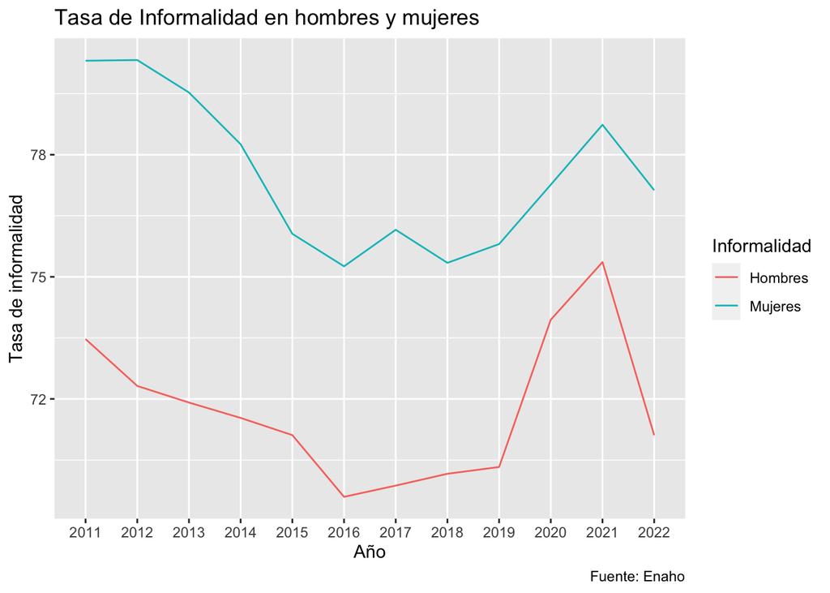

A su vez, la población ocupada informal por rangos de edades presentó incrementos de 7% para las personas de 14 a 24 años y de 5% para las personas de 25 a 44 años y de 45 a 64 años en 2021, respecto a las cifras prepandemia. No obstante, la población ocupada informal de 65 años a más en 2021 tuvo una reducción de 4,376 personas, respecto al 2019. Asimismo, la mayor parte de la población ocupada informal corresponde al rango de edades de 25 a 44 años (45%), seguido por el rango de 45 a 64 años (28%) y de 14 a 24 años (21%); y, finalmente, el rango de 65 a más (7%). Dicha distribución se ha mantenido en el último quinquenio, incluso con la crisis sanitaria de los años 2020 y 2021.

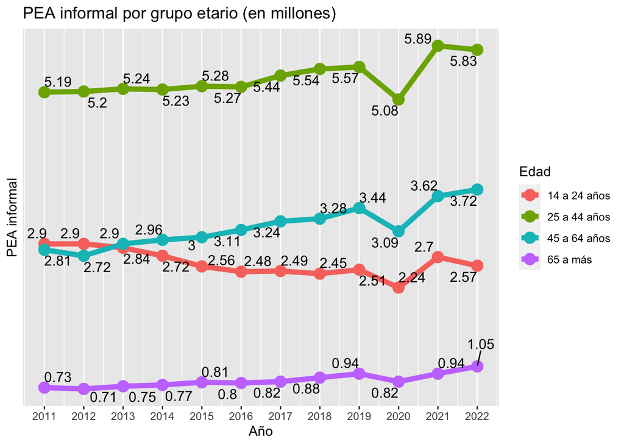

Respecto al tamaño de empresa, la mayor parte de la población ocupada informal suele acumularse en las microempresas de 1 a 10 trabajadores. Para el año 2019, representó el 89% del total de trabajadores informales. Debido a la aguda crisis del año 2020, la población informal de micro, pequeñas y medianas/grandes empresas se redujo en 849,747, 220,929 y 162,391 trabajadores, respectivamente en referencia al 2019. No obstante, para el año 2022 la población informal que labora en microempresas ha superado el nivel prepandemia; mientras que, la población informal de las pequeñas y medianas/grandes empresas ha presentado una recuperación importante aunque aún no alcanza niveles del 2019.

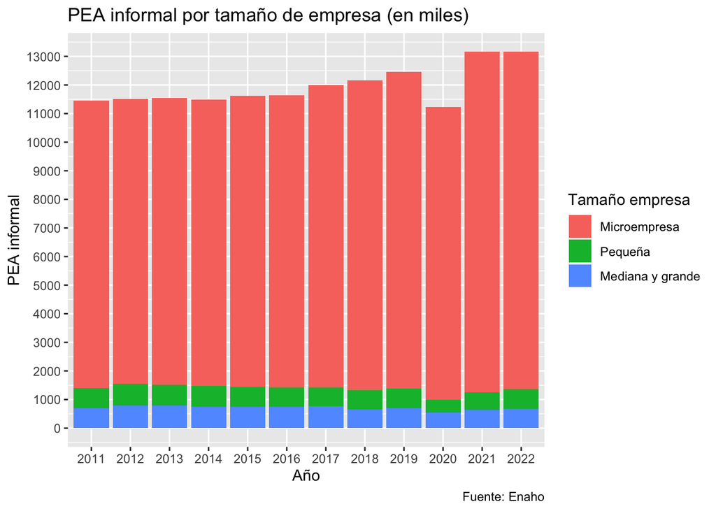

Los ingresos promedios mensuales formales e informales presentaban una dinámica similar para los años 2011 al 2019 con una tendencia al alza. Sin embargo, en el año 2020 se evidenció una reducción de ambos tipos de ingresos a causa de la pandemia siendo el más afectado el ingreso promedio formal el cual decreció en 136 soles; mientras que, el ingreso promedio informal se redujo en 108 soles. Asimismo, es relevante resaltar que para el año 2022, ambos ingresos promedio mensuales no sólo se han incrementado respecto al 2021 sino que han superado el nivel prepandemia.

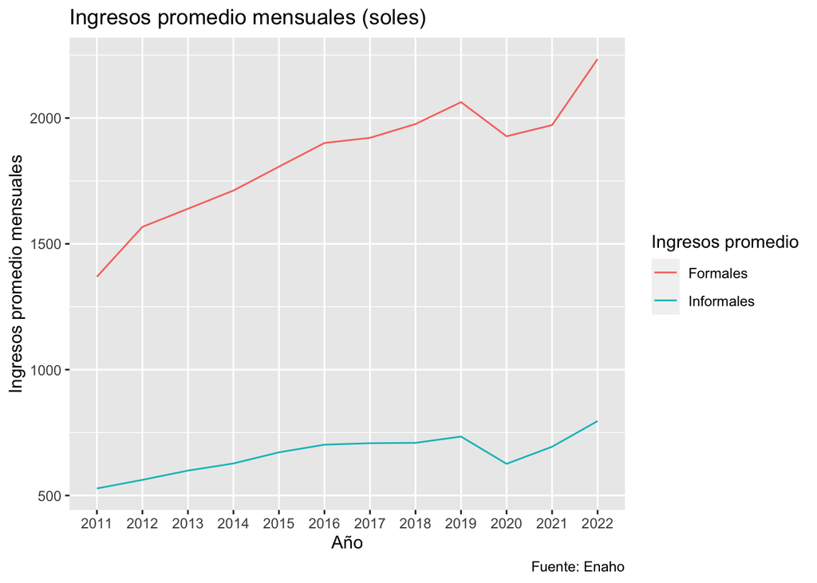

**Informalidad por regiones**

En el marco del análisis a nivel departamental, las regiones han seguido dinámicas diferenciadas. Así, en 2020 cuatro regiones redujeron su tasa de informalidad a pesar de la pandemia (Arequipa, Lambayeque, Lima y Tacna), aunque ello no necesariamente implica mejores condiciones laborales de los trabajadores de estas regiones, sino también esta asociado a la pérdida del empleo, un hecho con alta probabilidad para ese año. En esta línea, en 2020 es Pasco el departamento que incrementó su tasa de informalidad en mayor cuantía, ya que paso de 78.1% en 2019 a 87.0% en 2020.

En el 2021, todos los departamentos mostraron un incremento de su tasa de informalidad, registrando la menor diferencia en la región de La Libertad, con un aumento de 0.5 puntos porcentuales versus el periodo prepandemia. En tanto, la región con mayor crecimiento de su tasa de informalidad fue Ica que paso de 61.4% en 2019 a 69.1% en 2021.

Variaciones de la tasa de informalidad versus 2019

| Año | Menor incremento | Mayor incremento |
| --- | --- | --- |
| 2020 | Lambayeque: de 75.4% a 72.5% | Pasco: de 78.1% a 87.0% |
| 2021 | La Libertad: de 72.8% a 73.3% | Ica: de 61.4% a 69.1% |

En los últimos once años en promedio la región más informal del Perú es Huancavelica con una tasa de informalidad de 91.5%; en tanto, el departamento menos informal del Perú es la Provincia Constitucional del Callao (57.9%), seguido por Lima (59.4%). Ante el impacto del choque del COVID-19, esta estructura no se ha modificado para estas regiones; no obstante, el choque del COVID-19 si ha provocado cambios en las posiciones relativas de tasa de informalidad del resto de departamentos. Es así que entre 2020 y 2021, por ejemplo, Apurímac pasa de ser la sexta región con mayor tasa de informalidad a convertirse en la segunda región con mayor tasa de informalidad.

En esta línea, en el último año prepandemia, es decir en 2019, las regiones más informales son Huancavelica (92%), Cajamarca (87.9%) y Puno (87.6%); mientras que en 2021, si bien Huancavelica continúa siendo el departamento con mayor tasa de informalidad laboral (94.8%), ahora es seguido por Apurímac (90.6%) y Puno (90.4%), tal como lo muestran los cuadros y los mapas. Nuevamente Lima y Callao son las regiones con menor tasa de informalidad laboral.

Tasa de informalidad 2019 y 2021 por regiones

| Departamento | 2019 | 2021 |
| --- | --- | --- |
| HUANCAVELICA | 92.0 | 94.8 |
| CAJAMARCA | 87.9 | 89.4 |
| PUNO | 87.6 | 90.4 |
| AYACUCHO | 87.3 | 88.8 |
| HUANUCO | 86.6 | 89.7 |
| APURIMAC | 85.4 | 90.5 |

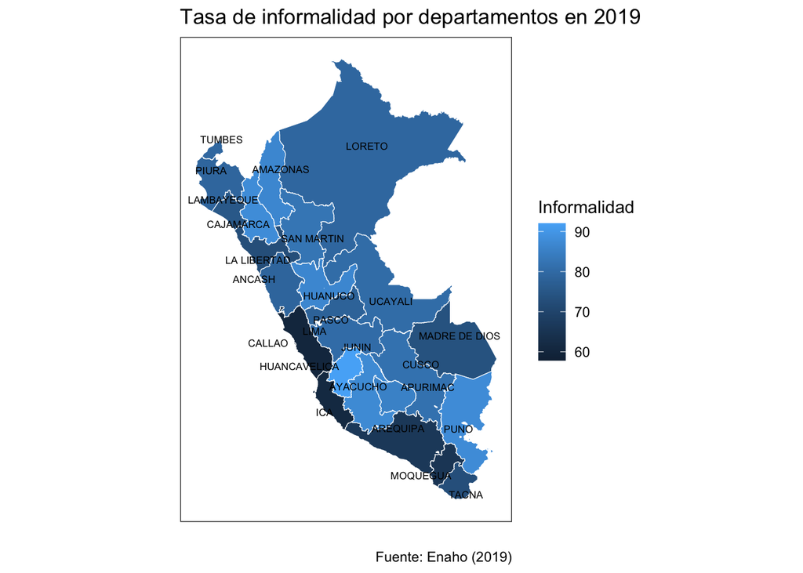

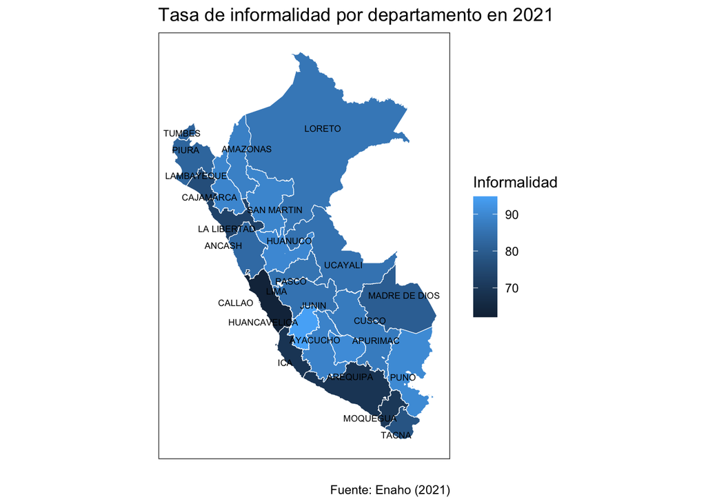

## V. Conclusiones

La informalidad es un problema estructural que en países como Perú se agudiza en mayor porporción por la falta de institucionalidad en el país, lo cual afecta de manera transversal a la poblacion sin importar el grupo etáreo, el tamaño de empresa, la zona de residencia o el sexo.

No obstante, se evidencia que históricamente algunos grupos (mujeres, zonas rurales, microempresas y grupo etáreo entre 25 y 44 años) se encuentran más vulnerables ante los diferentes choques que golpean la economía y con ello el mercado laboral. De esta manera, el COVID-19 generó un retroceso en los indicadores de informalidad, así la tasa de informalidad que se encontraba reduciendo de forma sistemática hasta 2019, aumetó en el 2020 a 75.3% (2.6 puntos porcentuales por encima de 2019) y en el 2021 a 76.8% en el 2021 (4.1 puntos porcentuales por encima de 2019).

Por su lado, a nivel departamental si bien las regiones con mayor (Huancavelica: 91.5% promedio 2011-2019) y menor (Callao: 57.9% promedio 2011-2019), Lima: 59.4% promedio 2011-2019)) tasa de informalidad continúan siendo las mismas, el choque del COVID-19 ha provocado cambios en las posiciones relativas de tasa de informalidad. Es así que entre 2020 y 2021, por ejemplo, Apurímac pasa de ser la sexta región con mayor tasa de informalidad a convertirse en la segunda región con mayor tasa de informalidad.

Finalmente, es relevante notar que los paquetes y librerias como *“tidyverse”*, *“ggplot”*, *“sf”*, *“purrr”*, *“ggrepel”*, *“gganimate”*, y *“reshape2”* proveyeron de las herramientos necesarias para poder realizar un análisis completo.

## Bibliografía

Arias, A. (2021). *R: Paquetes, librerías e importación de datos*. https://totumat.com/2021/04/23/r-librerias-datos/

GEOGPS. (2015). *GEO GPS PERÚ*. https://www.geogpsperu.com/2014/03/base-de-datos-peru-shapefile-shp-minam.html

Gestión. (2022). *Cerca de 1.8 millones de peruanos entraron a la informalidad laboral el 2021*. https://gestion.pe/economia/management-empleo/cerca-de-18-millones-de-peruanos-entraron-a-la-informalidad-laboral-el-2021-informalidad-laboral-inei-trabajo-sin-derechos-sociales-noticia/#:~:text=El%20reporte%20del%20INEI%20tambi%C3%A9n,932%2C500%20personas)%20en%20las%20mujeres.

Gonzalez, C. (2022). *Informalidad en perú: Raíces y trampas que explican el estancamiento económico*. https://www.america-retail.com/opinion/informalidad-en-peru-raices-y-trampas-que-explican-el-estancamiento-economico/

INEI. (2023). Instituto nacional de estadística e informática. *Lima, Perú*.

OIT. (2021). *Panorama laboral 2021. América latina y el caribe.* 272 p. https://www.ilo.org/wcmsp5/groups/public/---americas/---ro-lima/documents/publication/wcms_836196.pdf

ONU. (2015). *En américa latina, la informalidad laboral es un problema crónico*. https://news.un.org/es/audio/2015/04/1408961

Perry, G., Maloney, W., Arias, O., Fajnzylber, P., Mason, A., Saavedra-Chanduvi, J., & Bosch, M. (2007). *Informalidad: Escape y exclusión (estudios del banco mundial sobre américa latina y el caribe). Washington: Banco mundial*.

R. (2023). *The r project for statistical computing*. https://www.r-project.org/

Salazar-Xirinachs, J., José Manuel y Chacaltana. (2018). Políticas de formalización en américa latina: Avances y desafíos. *Lima, Perú: Organización Internacional Del Trabajo (ILO), Regional Office for Latin America and the Caribbean*.

Vargas-Espejo, V., & Vilchez Astucuri, J. (2016). Economía informal en perú: Situación actual y perspectivas. *Lima: Centro Nacional de Planeamiento Estratégico*.

[^1]: Al tercer trimestre del 2022.
[^2]: Se considera nivel prepandemia al año 2019.